# CH 3. 통계 실험 & 유의성 검정

### 통계적 유의성과 p값

통계적 유의성이란, 자신의 실험 결과가 우연히 일어난 것인지 아니면 극단적인 것인지를 판단하는 방법. 결과가 우연히 벌어질 수 있는 변동성의 바깥에 존재한다면 (우연히 일어날 확률이 낮다면) 우리는 이것을 통계적으로 유의하다고 말한다.

웹 테스트 결과를 가지고 분석해보자.

**전자 상거래 실험 결과**

가격 A : 전환 200 / 전환되지 않음 23539  
가격 B : 전환 182 / 전환되지 않음 22406

가격 A는 가격 B에 비해 약 5% 정도 우수한 결과를 보였다. 재표본추출 절차를 사용하면 가격 A와 B 간의 전환 차이가 우연에 의한 것인지 검정할 수 있다

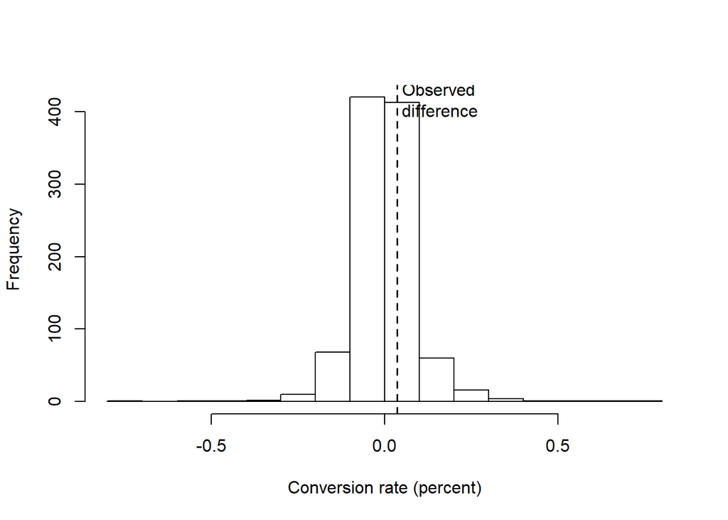

```r
perm_fun <- function(x, n1, n2)
{
  n <- n1 + n2
  idx_b <- sample(1:n, n1)
  idx_a <- sample(1:n, idx_b)
  mean_diff <- mean(x[idx_b]) - mean(x[idx_a])
  return(mean_diff)
}

obs_pct_diff <- 100*(200/23739 - 182/22588)
conversion <- c(rep(0, 45945), rep(1, 382))
perm_diffs <- rep(0, 1000)
for(i in 1:1000)
 perm_diffs[i] = 100*perm_fun(conversion, 23739, 22588)
hist(perm_diffs, xlab="Conversion rate (percent)", main='')
abline(v = obs_pct_diff, lty=2, lwd=1.5)
text(" Observed\n difference", x=obs_pct_diff, y=par()$usr[4]-20, adj=0)
```

### p 값

p 값은 통계적 유의성을 정확히 측정하기 위한 지표가 필요함

```r
mean(perm_diffs > obs_pct_diff)
```

```
## [1] 0.276
```

사실, 이 경우에는 p값을 얻기 위해 순열검정을 할 필요가 없다. 대신 정규분포를 사용하여 p값을 근사할 수도 있다.

```r
prop.test(x=c(200,182), n=c(23739,22588), alternative='greater')
```

```
##
##  2-sample test for equality of proportions with continuity correction
##
## data:  c(200, 182) out of c(23739, 22588)
## X-squared = 0.14893, df = 1, p-value = 0.3498
## alternative hypothesis: greater
## 95 percent confidence interval:
##  -0.001057439  1.000000000
## sample estimates:
##      prop 1      prop 2
## 0.008424955 0.008057376
```

인수 x는 각 그룹의 성공횟수이고, 인수 n은 시행 횟수이다.

### t 검정

t-test는 데이터가 수치형인 아주 일반적인 2표본 비교에 주료 사용됨

```r
session_times <- read.csv('C:/Users/newsY/Downloads/web_page_data.csv')
t.test(Time ~ Page, data=session_times, alternative='less')
```

```
##
##  Welch Two Sample t-test
##
## data:  Time by Page
## t = -1.0983, df = 27.693, p-value = 0.1408
## alternative hypothesis: true difference in means is less than 0
## 95 percent confidence interval:
##       -Inf 0.1959674
## sample estimates:
## mean in group Page A mean in group Page B
##             1.263333             1.620000
```

대안가설은 페이지 A에 대한 평균 세션이 B보다 작다는 것이다.

### 분산분석 (ANOVA)

여러 그룹 간의 통계적으로 유의미한 차이를 검정하는 통계적 절차

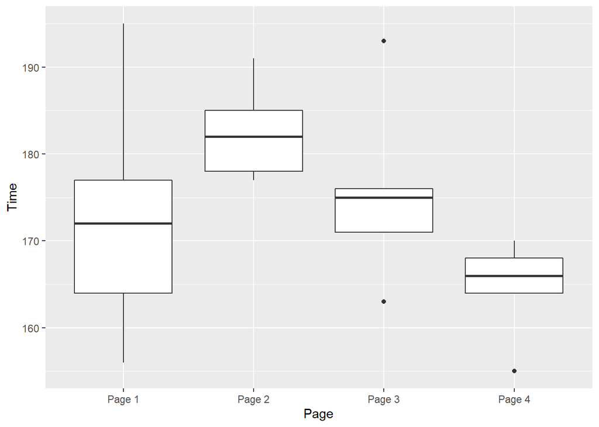

```r
four_sessions <- read.csv(file='C:/Users/newsY/Downloads/four_sessions.csv')

library(ggplot2)
ggplot(four_sessions, aes(x=Page, y=Time)) +
  geom_boxplot()
```

한 쌍씩 비교하는 횟수가 증가할수록 우연히 일어난 일에 속을 가능성이 커진다.

전체적인 총괄검정을 위해 ANOVA 실시

```r
library(lmPerm)
summary(aovp(Time ~ Page, data=four_sessions))
```

```
## [1] "Settings:  unique SS "
```

```
## Component 1 :
##             Df R Sum Sq R Mean Sq Iter Pr(Prob)
## Page         3    831.4    277.13 4068  0.07719 .
## Residuals   16   1618.4    101.15
## ---
## Signif. codes:  0 '***' 0.001 '**' 0.01 '*' 0.05 '.' 0.1 ' ' 1
```

### F 통계량

F 통계량은 잔차 오차 *residual error*로 인한 분산과 그룹 평균의 분산에 대한 비율을 기초로 한다.

이 비율이 높을수록 통계적으로 유의미함

```r
summary(aov(Time ~ Page, data=four_sessions))
```

```
##             Df Sum Sq Mean Sq F value Pr(>F)
## Page         3  831.4   277.1    2.74 0.0776 .
## Residuals   16 1618.4   101.2
## ---
## Signif. codes:  0 '***' 0.001 '**' 0.01 '*' 0.05 '.' 0.1 ' ' 1
```

Df는 자유도, Sum Sq는 제곱합, Mean Sq는 평균 제곱, F value는 F 통계량 가르킴